# Perturb Seq 2022

Andrew Chen

2022-11-29

# Basic EDA

```r
k562_essential_normalized_bulk_data$X[1:5, 1:5]
```

```
##                                    ENSG00000237491 ENSG00000228794
## 10023_ZC3H18_P1P2_ENSG00000158545      -0.01371926    -0.132440820
## 10029_ZC3H8_P1P2_ENSG00000144161       -0.35769591     0.109481782
## 10040_ZCCHC9_P1P2_ENSG00000131732      -0.06879387    -0.003540303
## 10041_ZCRB1_P1P2_ENSG00000139168        0.11270187     0.040670067
## 1004_C17orf58_P1P2_ENSG00000186665      0.06225708     0.165865868
##                                    ENSG00000188976 ENSG00000187961
## 10023_ZC3H18_P1P2_ENSG00000158545      -0.21942092      0.15091890
## 10029_ZC3H8_P1P2_ENSG00000144161        0.42188421      0.09244080
## 10040_ZCCHC9_P1P2_ENSG00000131732       0.21358865     -0.03407533
## 10041_ZCRB1_P1P2_ENSG00000139168        0.01152906      0.04515928
## 1004_C17orf58_P1P2_ENSG00000186665     -0.17651612     -0.02661255
##                                    ENSG00000188290
## 10023_ZC3H18_P1P2_ENSG00000158545       0.03933383
## 10029_ZC3H8_P1P2_ENSG00000144161       -0.10934170
## 10040_ZCCHC9_P1P2_ENSG00000131732      -0.16423745
## 10041_ZCRB1_P1P2_ENSG00000139168       -0.07482056
## 1004_C17orf58_P1P2_ENSG00000186665     -0.13357754
```

```r
dim(k562_essential_normalized_bulk_data)
```

```
## [1] 2285 8563
```

> 2285 perturbations (all common essential genes), and the effect on expression for 8563 genes. In Ann Data, samples are row, and features (gene expression) are columns. Information about the features is contained in obj$var, and information about the sample are contained in obj$obs

```r
k562_all_normalized_bulk_data %>% dim
```

```
## [1] 11258  8248
```

> Genome wide screen has 11,258 perturbations, for fewer genes.

```r
k562_essential_normalized_bulk_data$obs$UMI_count_unfiltered %>% median(na.rm=TRUE)
```

```
## [1] 13467.46
```

> Median > 10,000 UMIs per cell.

```r
k562_essential_normalized_bulk_data$obs$num_cells_filtered %>% median(na.rm=TRUE)
```

```
## [1] 116
```

# TP53 Perturbation

```r
tp53_filter_bulk <- k562_essential_normalized_bulk_data$obs %>% rownames %>% grepl("TP53", x=., fixed=TRUE)
k562_tp53_bulk <- k562_essential_normalized_bulk_data[tp53_filter_bulk,]$X
k562_tp53_bulk[1,1:5]
```

```
## ENSG00000237491 ENSG00000228794 ENSG00000188976 ENSG00000187961 ENSG00000188290
##     0.039044052     0.014904844    -0.093510695    -0.006598883     0.084913142
```

```r
rownames(k562_tp53_bulk)
```

```
## [1] "9194_TP53RK_P1P2_ENSG00000172315"
## attr(,"name")
## [1] "gene_transcript"
```

```r
tp53_filter_gwps <- k562_all_normalized_bulk_data$obs %>% rownames %>% grepl("TP53", x=., fixed=TRUE)
k562_tp53_gwps <- k562_all_normalized_bulk_data[tp53_filter_gwps,]$X
k562_tp53_gwps[, 1:5]
```

```
##                                   ENSG00000237491 ENSG00000228794
## 9189_TP53BP1_P1_ENSG00000067369       -0.04042027     -0.09866818
## 9190_TP53BP1_P2_ENSG00000067369        0.07215087     -0.01409887
## 9191_TP53BP2_P1P2_ENSG00000143514     -0.01334050     -0.04594798
## 9192_TP53I13_P1P2_ENSG00000167543     -0.03620545      0.08462203
## 9193_TP53I3_P1P2_ENSG00000115129       0.14327979     -0.00434673
## 9194_TP53RK_P1P2_ENSG00000172315      -0.07356911     -0.09140216
## 9195_TP53_P1P2_ENSG00000141510        -0.03268535      0.01679628
##                                   ENSG00000188976 ENSG00000187961
## 9189_TP53BP1_P1_ENSG00000067369        0.07097746     -0.01109619
## 9190_TP53BP1_P2_ENSG00000067369       -0.03539795     -0.11968724
## 9191_TP53BP2_P1P2_ENSG00000143514     -0.10090306     -0.02277748
## 9192_TP53I13_P1P2_ENSG00000167543     -0.08712301     -0.01559768
## 9193_TP53I3_P1P2_ENSG00000115129       0.02697378      0.01999694
## 9194_TP53RK_P1P2_ENSG00000172315      -0.15252790      0.08087446
## 9195_TP53_P1P2_ENSG00000141510        -0.02921239      0.19468474
##                                   ENSG00000188290
## 9189_TP53BP1_P1_ENSG00000067369      -0.078595325
## 9190_TP53BP1_P2_ENSG00000067369       0.011943522
## 9191_TP53BP2_P1P2_ENSG00000143514     0.042936228
## 9192_TP53I13_P1P2_ENSG00000167543     0.022559384
## 9193_TP53I3_P1P2_ENSG00000115129     -0.142977223
## 9194_TP53RK_P1P2_ENSG00000172315     -0.037108589
## 9195_TP53_P1P2_ENSG00000141510        0.001997438
```

> Raw values are different, compare row 6 values. Genome wide screen was a seperate experiment done on day 8, the essential gene screen was another experiment done on day 6.

```r
k562_controls_filter <- k562_essential_normalized_bulk_data$obs %>% rownames %>% grepl("non-targeting", x=., fixed=TRUE)
k562_essential_normalized_bulk_data[k562_controls_filter,1:5]$X %>% head
```

```
##                                                 ENSG00000237491 ENSG00000228794
## 10753_non-targeting_non-targeting_non-targeting     0.203176394    -0.064987972
## 10759_non-targeting_non-targeting_non-targeting     0.015431363    -0.185498521
## 10760_non-targeting_non-targeting_non-targeting     0.045781851    -0.008961129
## 10772_non-targeting_non-targeting_non-targeting    -0.156177521    -0.184858531
## 10782_non-targeting_non-targeting_non-targeting     0.127940848     0.059391532
## 10783_non-targeting_non-targeting_non-targeting    -0.003332305    -0.091220021
##                                                 ENSG00000188976 ENSG00000187961
## 10753_non-targeting_non-targeting_non-targeting    -0.077147968     -0.15795022
## 10759_non-targeting_non-targeting_non-targeting    -0.061678115     -0.06525984
## 10760_non-targeting_non-targeting_non-targeting    -0.137292966     -0.06622776
## 10772_non-targeting_non-targeting_non-targeting    -0.109522134      0.03464487
## 10782_non-targeting_non-targeting_non-targeting    -0.006873527     -0.20105316
## 10783_non-targeting_non-targeting_non-targeting    -0.067228869     -0.05277672
##                                                 ENSG00000188290
## 10753_non-targeting_non-targeting_non-targeting      0.06891780
## 10759_non-targeting_non-targeting_non-targeting      0.02295318
## 10760_non-targeting_non-targeting_non-targeting     -0.10663816
## 10772_non-targeting_non-targeting_non-targeting      0.03095308
## 10782_non-targeting_non-targeting_non-targeting      0.03902240
## 10783_non-targeting_non-targeting_non-targeting      0.11123554
```

Is TP53 suppressed?

```r
k562_tp53_bulk[,"ENSG00000172315"]
```

```
## [1] -0.6992992
```

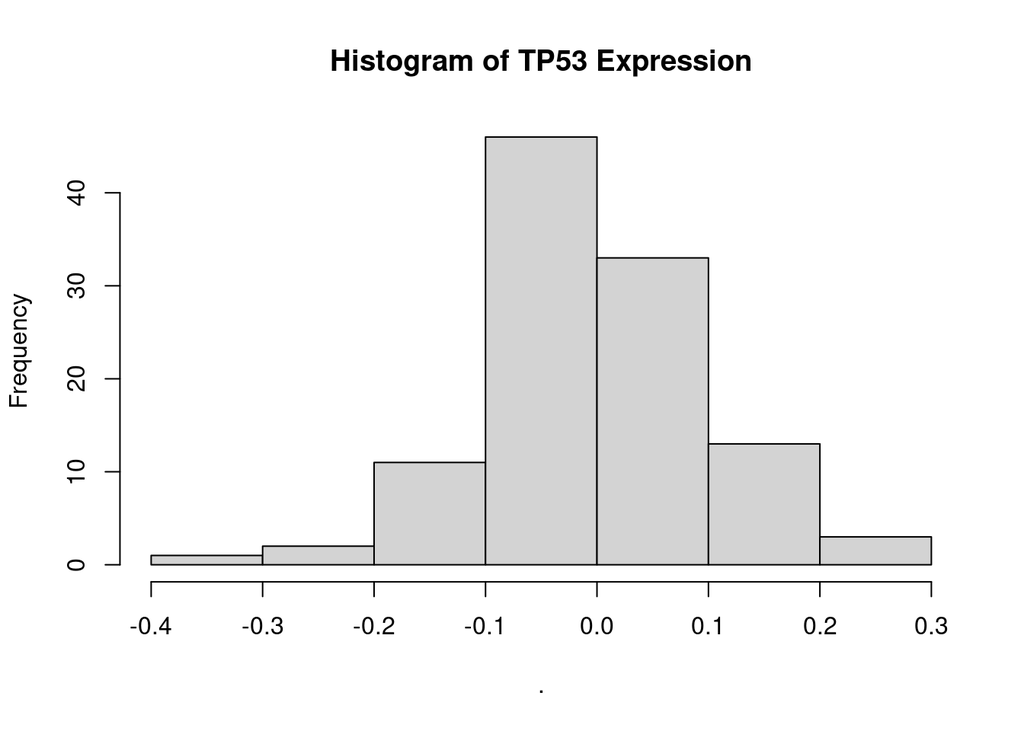

```r
k562_essential_normalized_bulk_data[k562_controls_filter,"ENSG00000172315"]$X %>% hist(main= "Histogram of TP53 Expression")
```

```r
#' Fetch the genes that are over/under expressed as a result of a perturbation in Perturb Seq experiments
#'
#' @param ann_data ann_data R object
#' @param gene hgnc gene symbol
#' @param cutoff ordinal number, or fraction if you want the top 5%. If NULL, no cutoff is applied
#'
#' @export
perturb_seq_sig <- function(ann_data, gene, cutoff=NULL) {

  gene_filter <- ann_data$obs %>% rownames %>% grepl(gene, x=., fixed=TRUE)
  controls_filter <- ann_data$obs %>% rownames %>% grepl("non-targeting", x=., fixed=TRUE)

  gene_exp <- ann_data[gene_filter,]$X

  if(nrow(gene_exp) > 1) {
    # Find average expression of target gene
    gene_exp <- apply(gene_exp, MARGIN = 2, FUN = mean)
  } else {
    # Or if there's only one row
    gene_exp <- gene_exp[1,]
  }

  control_mean <- apply(ann_data[controls_filter,]$X, MARGIN = 2, FUN = mean)
  control_sd <- apply(ann_data[controls_filter,]$X, MARGIN = 2, FUN = sd)

  # Perhaps can use a p-value based cutoff instead of top n
  diff <- (gene_exp - control_mean)/control_sd

  if (is.null(cutoff)) {
    n_cut <- length(diff)
  } else if (cutoff < 1) {
    n_cut <- round(cutoff * ann_data$n_vars)
  } else {
    n_cut <- cutoff
  }

  diff_up <- diff[order(diff, decreasing=TRUE)[1:n_cut]]
  diff_down <- diff[order(diff, decreasing=FALSE)[1:n_cut]]

  up_symbol <- as.character(ann_data$var[names(diff_up), "gene_name"])
  down_symbol <- as.character(ann_data$var[names(diff_down), "gene_name"])

  return(list(up = up_symbol, down = down_symbol))
}
```

```r
library(vennr)
tp53_gwps <- perturb_seq_sig(k562_all_normalized_bulk_data, "TP53", 0.01)
tp53_essential <- perturb_seq_sig(k562_essential_normalized_bulk_data, "TP53", 0.01)
names(tp53_gwps) <- c("gwps_up", "gwps_down")
vennr(c(tp53_gwps, tp53_essential))
```

[interactive chart not shown]

> Genome wide screen produces signatures that don’t overlap too much with the bulk.

```r
tp53_rpe1_essential <- perturb_seq_sig(rpe1_essential_normalized_bulk_data, "TP53", 0.01)
vennr(list(k562_up = tp53_essential$up, k562_down = tp53_essential$down, rpe1_up = tp53_rpe1_essential$up, rpe1_down = tp53_rpe1_essential$down))
```

[interactive chart not shown]

> TP53 crispri knockdown produces different signatures in the two cell lines.

```r
savepath <- file.path(Sys.getenv("MLAB"), "projects/brcameta/sig_recon/data")
saveRDS(tp53_essential, file=file.path(savepath, "tp53_k562_ps_sig.rds"))
saveRDS(tp53_rpe1_essential, file=file.path(savepath, "tp53_rpe1_ps_sig.rds"))
saveRDS(perturb_seq_sig(k562_essential_normalized_bulk_data, "TP53"), file=file.path(savepath, "tp53_k562_ps_sig_all.rds"))
saveRDS(perturb_seq_sig(rpe1_essential_normalized_bulk_data, "TP53"), file=file.path(savepath, "tp53_rpe1_ps_sig_all.rds"))
```

# K562 SC Data

```r
k562_essential_normalized_sc_data$obs
```

|  | gem_group | gene | gene_id | transcript | gene_transcript | sgID_AB | mitopercent | UMI_count | z_gemgroup_UMI | core_scale_factor | core_adjusted_UMI_count |
| --- | --- | --- | --- | --- | --- | --- | --- | --- | --- | --- | --- |
| AAACCCAAGAAATCCA-27 | 27 | NAF1 | ENSG00000145414 | P1P2 | 5449_NAF1_P1P2_ENSG00000145414 | NAF1_+_164087918.23-P1P2\|NAF1_-_164087674.23-P1P2 | 0.112082534 | 11438 | 0.0130468644 | 0.8132525 | 14064.513 |
| AAACCCAAGAACTTCC-31 | 31 | BUB1 | ENSG00000169679 | P1P2 | 935_BUB1_P1P2_ENSG00000169679 | BUB1_-_111435363.23-P1P2\|BUB1_-_111435372.23-P1P2 | 0.179895177 | 5342 | -1.5222473145 | 0.8441066 | 6328.584 |
| AAACCCAAGAAGCCAC-34 | 34 | UBL5 | ENSG00000198258 | P1P2 | 9534_UBL5_P1P2_ENSG00000198258 | UBL5_-_9938639.23-P1P2\|UBL5_+_9938801.23-P1P2 | 0.105287492 | 17305 | 0.3841572702 | 1.0915369 | 15853.793 |
| AAACCCAAGAATAGTC-43 | 43 | C9orf16 | ENSG00000171159 | P1P2 | 1131_C9orf16_P1P2_ENSG00000171159 | C9orf16_+_130922603.23-P1P2\|C9orf16_+_130922642.23-P1P2 | 0.099358551 | 30244 | 3.7219119072 | 0.9482775 | 31893.619 |
| AAACCCAAGACAGCGT-28 | 28 | TIMM9 | ENSG00000100575 | P1P2 | 8927_TIMM9_P1P2_ENSG00000100575 | TIMM9_-_58893843.23-P1P2\|TIMM9_-_58893848.23-P1P2 | 0.137623414 | 8407 | -0.9753714800 | 0.8689424 | 9674.979 |
| AAACCCAAGACATGCG-10 | 10 | SMG5 | ENSG00000198952 | P1P2 | 8166_SMG5_P1P2_ENSG00000198952 | SMG5_+_156252585.23-P1P2\|SMG5_-_156252584.23-P1P2 | 0.079490498 | 20883 | 1.7325608730 | 0.9570653 | 21819.828 |
| AAACCCAAGACCATTC-19 | 19 | ZNF687 | ENSG00000143373 | P1P2 | 10553_ZNF687_P1P2_ENSG00000143373 | ZNF687_-_151254788.23-P1P2\|ZNF687_+_151255019.23-P1P2 | 0.111504242 | 19219 | 0.7144578695 | 1.1233844 | 17108.125 |
| AAACCCAAGAGCTGCA-34 | 34 | MED9 | ENSG00000141026 | P1P2 | 4959_MED9_P1P2_ENSG00000141026 | MED9_-_17380350.23-P1P2\|MED9_-_17380394.23-P1P2 | 0.150697559 | 7598 | -1.4550962448 | 1.0915369 | 6960.828 |
| AAACCCAAGAGGCGTT-11 | 11 | RPL3 | ENSG00000100316 | P1P2 | 7472_RPL3_P1P2_ENSG00000100316 | RPL3_+_39715369.23-P1P2\|RPL3_+_39715378.23-P1P2 | 0.102387302 | 15373 | 0.1425342560 | 1.0501878 | 14638.334 |
| AAACCCAAGAGTTGCG-19 | 19 | PSTK | ENSG00000179988 | P1 | 6892_PSTK_P1_ENSG00000179988 | PSTK_+_124739974.23-P1\|PSTK_-_124739917.23-P1 | 0.095804296 | 20521 | 0.9766746163 | 1.1233844 | 18267.123 |

[output cut: 9990 more lines]

```r
k562_essential_normalized_sc_data$obs$gene %>% table %>% sort(decreasing=TRUE) %>% head
```

```
## .
## non-targeting          RPL3         NCBP2         KIF11       SLC39A9
##         10691          1996           992           974           752
##        DONSON
##           745
```

> Most frequent sgRNA gene targets

```r
k562_essential_normalized_sc_data$obs$gene %>% table %>% quantile
```

```
##    0%   25%   50%   75%  100%
##     5    78   121   181 10691
```

> For the K562 single cell data. Each row is a single cell. Each cell seems to have been perturbed w/r to one gene. The perturbation of each gene has many replicates, often > 100.

```r
sc_tp53_filter <- grepl("TP53", x=k562_essential_normalized_sc_data$obs$gene, fixed=TRUE)
sc_tp53_data <- k562_essential_normalized_sc_data[sc_tp53_filter,]$X

sc_tp53_data_mean <- apply(sc_tp53_data, 2, mean)

all.equal.numeric(sc_tp53_data_mean,k562_tp53_bulk[1,])
```

```
## [1] "Mean relative difference: 3.569063e-08"
```

> Bulk is just a mean of the single cell.